# Actividad1

2023-08-13

options(encoding = “UTF-8”)

# Actividad 1

## Caso : Análisis del mercado inmobiliario en Cali

# Indice

1.Introducción

2.Objetivos

3.Métodos

4.Resultados

5.Discusión

6.Conclusiones

7.Anexos

## Introducción

Este informe estadístico se erige como una herramienta valiosa para B&C. A través de este estudio se realizara un analisis de las fluctuaciones en el precio de las viviendas en diversas áreas de Cali, sopesaremos las preferencias de la comunidad y revelaremos las características que despiertan el interésde los compradores. En esencia, este informe es un faro que guía a la empresa en la toma de decisiones, destilando una visión clara de su nicho de mercado, orquestando estrategias de marketing efectivas, estableciendo precios de venta adecuados y tejiendo una red de servicios personalizados.

Así, mientras B&C se adentra en el tejido de la comunidad inmobiliaria de Cali, esperamos que con el uso de las herramientas analiticas que se presentan la empresa logre encontrar una posición privilegiada para llevar a cabo transformaciones significativas, impulsar el desarrollo económico regional y no ser solo un agente de bienes raíces, sino un guía confiable y un socio en los sueños de los buscadores de hogares.

## Objetivos

Este informe estadístico se presenta como una herramienta estratégica con el propósito de guiar sus decisiones empresariales basado en la muestra de datos otorgada. Con los siguientes objetivos:

**Identificar Oportunidades de Negocio:** El objetivo principal de este informe es descubrir y evaluar las áreas de mayor potencial de negocio para B&C en el mercado de bienes raíces de Cali. Mediante el análisis de datos, se pretende identificar las zonas geográficas y segmentos de mercado que presenten oportunidades prometedoras para el crecimiento y expansión de la empresa.

**Analizar el Crecimiento por Zonas:** Se busca llevar a cabo un análisis comparativo de las distintas áreas de Cali para determinar cuáles están experimentando un crecimiento más dinámico en términos de precio de viviendas, demanda del mercado y preferencias de los compradores. Este análisis permitirá a B&C focalizar sus esfuerzos y recursos en las regiones con mayor potencial de rentabilidad.

**Aplicar Métodos Estadísticos Relevantes:** Para lograr resultados confiables y significativos, se emplearán métodos estadísticos fundamentales en el análisis de datos que permitirán examinar patrones, variaciones y relaciones en los datos recopilados, proporcionando una base sólida para la toma de decisiones informada.

## Métodos

Iniciamos realizando la importación de librerias ncesarias para nuestro proceso.

```r
#install.packages('mice')install.packages("VIM")
if(!require(mice)){
  install.packages(mice)

}
library(mice)

# Instalaremos y cargaremos la librería ggplot2 si aún no está instalada
if (!require(ggplot2)) {
  install.packages("ggplot2")
}
library(ggplot2)

if(!require(VIM)){
  install.packages(VIM)

}
library(VIM)

if(!require(dplyr)){
  install.packages(dplyr)

}
library(dplyr)

if (!require(treemap)) {
  install.packages("treemap")
}
library(treemap)

if(!require(readr)){
  install.packages(readr)
}
library(readr)
```

Primero importamos los datos:

```r
data_viviendas <- read.csv("~/Personal/Javeriana/Maestria/MetodosSimulacionEstadistica/vivienda_faltantes.csv")
head(data_viviendas)
```

```
##     id       zona piso estrato preciom areaconst parquea banios habitac
## 1 8312 Zona Oeste    4       6    1300       318       2      4       2
## 2 8311 Zona Oeste    1       6     480       300       1      4       4
## 3 8307 Zona Oeste   NA       5    1200       800       4      7       5
## 4 8296   Zona Sur    2       3     220       150       1      2       4
## 5 8297 Zona Oeste   NA       5     330       112       2      4       3
## 6 8298   Zona Sur   NA       5    1350       390       8     10      10
##          tipo           barrio longitud latitud
## 1 Apartamento         arboleda   -76576    3454
## 2        Casa        normandía   -76571    3454
## 3        Casa       miraflores   -76568    3455
## 4        Casa        el guabal   -76565    3417
## 5        Casa bella suiza alta   -76565    3408
## 6        Casa bella suiza alta   -76565    3409
```

El resumen de la base de datos:

```r
summary(data_viviendas)
```

```
##        id           zona                piso           estrato
##  Min.   :   1   Length:8330        Min.   : 1.000   Min.   :3.000
##  1st Qu.:2082   Class :character   1st Qu.: 2.000   1st Qu.:4.000
##  Median :4164   Mode  :character   Median : 3.000   Median :5.000
##  Mean   :4164                      Mean   : 3.772   Mean   :4.634
##  3rd Qu.:6246                      3rd Qu.: 5.000   3rd Qu.:5.000
##  Max.   :8319                      Max.   :12.000   Max.   :6.000
##  NA's   :3                         NA's   :2641     NA's   :3
##     preciom         areaconst       parquea           banios
##  Min.   :  58.0   Min.   :  30   Min.   : 1.000   Min.   : 0.000
##  1st Qu.: 220.0   1st Qu.:  80   1st Qu.: 1.000   1st Qu.: 2.000
##  Median : 330.0   Median : 123   Median : 2.000   Median : 3.000
##  Mean   : 434.2   Mean   : 175   Mean   : 1.836   Mean   : 3.112
##  3rd Qu.: 540.0   3rd Qu.: 229   3rd Qu.: 2.000   3rd Qu.: 4.000
##  Max.   :1999.0   Max.   :1745   Max.   :10.000   Max.   :10.000
##  NA's   :2        NA's   :3      NA's   :1606     NA's   :3
##     habitac           tipo              barrio             longitud
##  Min.   : 0.000   Length:8330        Length:8330        Min.   :-76576.00
##  1st Qu.: 3.000   Class :character   Class :character   1st Qu.:-76506.00
##  Median : 3.000   Mode  :character   Mode  :character   Median :   -76.54
##  Mean   : 3.605                                         Mean   :-21845.13
##  3rd Qu.: 4.000                                         3rd Qu.:   -76.52
##  Max.   :10.000                                         Max.   :   -76.46
##  NA's   :3                                              NA's   :3
##     latitud
##  Min.   :   3.333
##  1st Qu.:   3.390
##  Median :   3.450
##  Mean   : 970.370
##  3rd Qu.:3367.000
##  Max.   :3497.000
##  NA's   :3
```

Si analizamos el comportamiento de datos perdidos, encontramos que:

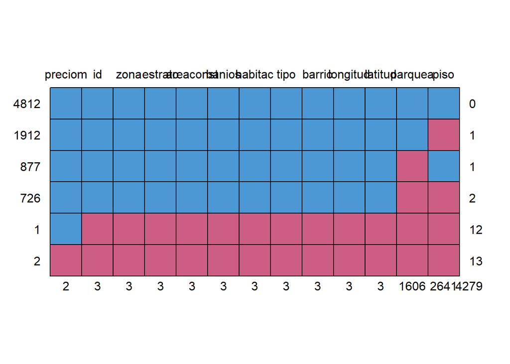

```
##      preciom id zona estrato areaconst banios habitac tipo barrio longitud
## 4812       1  1    1       1         1      1       1    1      1        1
## 1912       1  1    1       1         1      1       1    1      1        1
## 877        1  1    1       1         1      1       1    1      1        1
## 726        1  1    1       1         1      1       1    1      1        1
## 1          1  0    0       0         0      0       0    0      0        0
## 2          0  0    0       0         0      0       0    0      0        0
##            2  3    3       3         3      3       3    3      3        3
##      latitud parquea piso
## 4812       1       1    1    0
## 1912       1       1    0    1
## 877        1       0    1    1
## 726        1       0    0    2
## 1          0       0    0   12
## 2          0       0    0   13
##            3    1606 2641 4279
```

```r
md.pattern(data_viviendas)
```

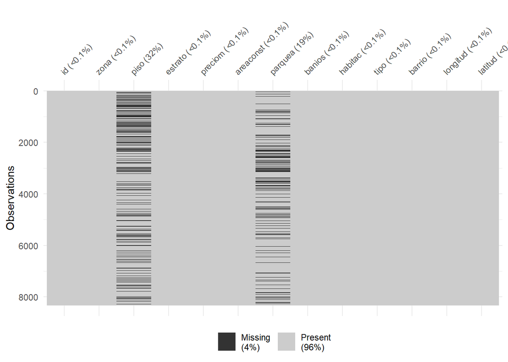

```r
if (!require(naniar)) {
  install.packages("naniar")
}
library(naniar)

vis_miss(data_viviendas)
```

A partir del gráfico anterior, es evidente que existen tres registros con valores nulos en la columna “id”. Estos registros serán eliminados, considerando que esta columna debe contener valores únicos y no puede admitir valores nulos.

#### Limpieza y Transformación de Datos

```r
data_viviendas <- data_viviendas[complete.cases(data_viviendas$id), ]
```

```r
data_viviendas <- data_viviendas[complete.cases(data_viviendas$areaconst), ]
```

Una vez realizada la limpieza procedemos a eliminar las tildes y caracteres especiales que estaban contenidos en nuestros registros y generaba una división de los datos, para ello realizamos los siguientes procesos:

```r
# Eliminar las tildes y estandarizar la columna "barrio"
data_viviendas <- data_viviendas %>%
  mutate(barrio = iconv(barrio, to = "ASCII//TRANSLIT"))
```

```r
# Reemplazar '?C' por 'e' en la columna "barrio"
data_viviendas <- data_viviendas %>%
  mutate(barrio = gsub("\\?C", "e", barrio))
```

```r
# Reemplazar 'APARTAMENTO' por 'apartamento' en la columna "tipo"
data_viviendas <- data_viviendas %>%
  mutate(tipo = gsub("\\APARTAMENTO", "apartamento", tipo)) %>%
  mutate(tipo = gsub("\\Apartamento", "apartamento", tipo))
```

```r
# Reemplazar 'el ingenio' por 'ingenio' en la columna "barrio"
data_viviendas <- data_viviendas %>%
  mutate(barrio = gsub('el ingenio', 'ingenio', barrio))
```

## Resultados

A continuación, vamos a proceder a estudiar nuestro datos mediante forma grafica para poder realizar un mejor analisis.

```r
# Instalaremos y cargaremos la librería ggplot2 si aún no está instalada
if (!require(ggplot2)) {
  install.packages("ggplot2")
}
library(ggplot2)
```

Comenzaremos por identificar las zonas en nuestra base de datos que poseen un mayor número de registros. En esta etapa, se busca establecer una correlación entre la cantidad de registros y la calidad del análisis, considerando que un mayor volumen de datos conlleva a un análisis más sólido y detallado.

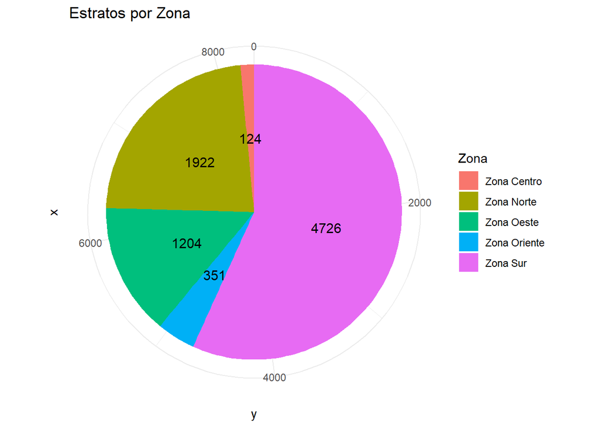

```r
# Creamos el gráfico circular con etiquetas de valor centradas y radio expandido
grafico_pie <- ggplot(data_viviendas, aes(x = "", fill = zona)) +
  geom_bar(stat = "count", width = 1) +
  geom_text(aes(label = ..count..), stat = "count", position = position_stack(vjust = 0.5), size = 4) +  # Etiquetas centradas y más grandes
  coord_polar(theta = "y") +
  expand_limits(y = c(0, max(data_viviendas$count) + 20)) +  # Expandir el radio del gráfico
  labs(title = "Estratos por Zona",
       fill = "Zona") +
  theme_minimal()

print(grafico_pie)
```

A partir del gráfico anterior, podemos notar que la zona sur registra la mayor cantidad de datos. Ahora, siguiendo nuestra explicación previa, nos adentraremos en un análisis más detallado de esta zona mas adelante.

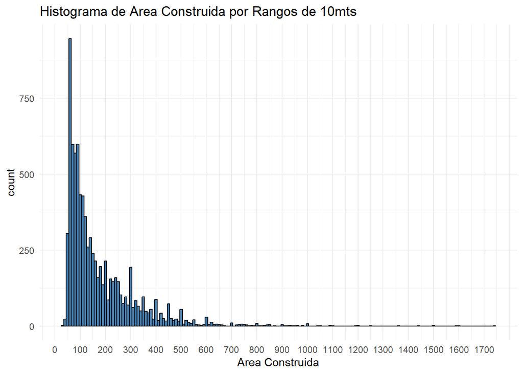

```r
# Crear un histograma con rangos de 10 en el campo "areconst"
grafico_histograma <- ggplot(data_viviendas, aes(x = areaconst)) +
  geom_histogram(binwidth = 10, fill = "steelblue", color = "black") +
  labs(title = "Histograma de Area Construida por Rangos de 10mts",
       x = "Area Construida") +
  scale_x_continuous(breaks = seq(0, max(data_viviendas$areaconst), by = 100)) +
    theme_minimal()
print(grafico_histograma)
```

Calcular la moda de la muestra de datos representada en el histograma previo será esencial para establecer una submuestra de estudio más precisa. Por consiguiente:

```r
#Función para obtener la moda de una tabla en función de la columna definida.
mode <- function(x) {
   return(as.numeric(names(which.max(table(x)))))
}

mode(data_viviendas$areaconst) # 1
```

```
## [1] 60
```

#### Análisis De Los Costos De Las Propiedades Por Zona Para Una Rango De Datos

En la tabla subsiguiente, se refleja la influencia de nuestras observaciones en el histograma previo. En consecuencia, hemos seleccionado un intervalo de área construida entre 55 y 65 metros, definiendo además los valores máximos y mínimos de las propiedades dentro de este rango.

```r
if (!require(dplyr)) {
  install.packages("dplyr")
}
library(dplyr)

resultados <- data_viviendas %>%
  filter(areaconst >= 55 & areaconst<= 65) %>%
  group_by(zona) %>%
  count() %>%
  left_join(data_viviendas %>%
              filter(areaconst >= 55 & areaconst<= 65) %>%
              group_by(zona) %>%
              summarize(minimo = min(preciom, na.rm = TRUE),
                        maximo = max(preciom, na.rm = TRUE)),
            by = "zona") %>%
  select(zona, cantidad_registros = n, minimo, maximo)

print(resultados)
```

```
## # A tibble: 5 × 4
## # Groups:   zona [5]
##   zona         cantidad_registros minimo maximo
##   <chr>                     <int>  <int>  <int>
## 1 Zona Centro                   3    108    162
## 2 Zona Norte                  343     65    420
## 3 Zona Oeste                   54     85    387
## 4 Zona Oriente                 37     62    155
## 5 Zona Sur                    600     75    515
```

En virtud de esta evaluación, resalta que las propiedades de mayor valor se localizan en las zonas norte, sur y oeste, mientras que las más asequibles se encuentran en las zonas centro y oriente. Dado que nuestra muestra de datos se concentra mayormente en la zona sur, resulta sensato llevar a cabo un análisis más exhaustivo de este territorio, debido a la profusión de registros, lo cual podría implicar un mayor interés para nuestra investigación.

Siguiendo esta línea de pensamiento, procederemos a examinar la cantidad de registros por barrio en dicha zona. A tal efecto, presentamos la siguiente tabla:

```r
resultados_barrios_sur <- data_viviendas %>%
  filter(zona == "Zona Sur") %>%
  group_by(barrio) %>%
  count() %>%
  select(barrio, cantidad_registros = n) %>%
  arrange(desc(cantidad_registros))

print(resultados_barrios_sur)
```

```
## # A tibble: 199 × 2
## # Groups:   barrio [199]
##    barrio         cantidad_registros
##    <chr>                       <int>
##  1 valle del lili               1004
##  2 ciudad jardin                 535
##  3 pance                         408
##  4 el caney                      208
##  5 ingenio                       203
##  6 la hacienda                   164
##  7 el limonar                    135
##  8 el refugio                    120
##  9 ciudad 2000                    95
## 10 caney                          88
## # ℹ 189 more rows
```

Los datos que se encuentran en la tabla anterior se pueden observar de igual forma en el siguiente grafico de mosaico, con lo cual consideramos que los barrios en los que vamos a enfocar nuestro estudio seran: Valle del lili, Ciudad Jardín y Pance.

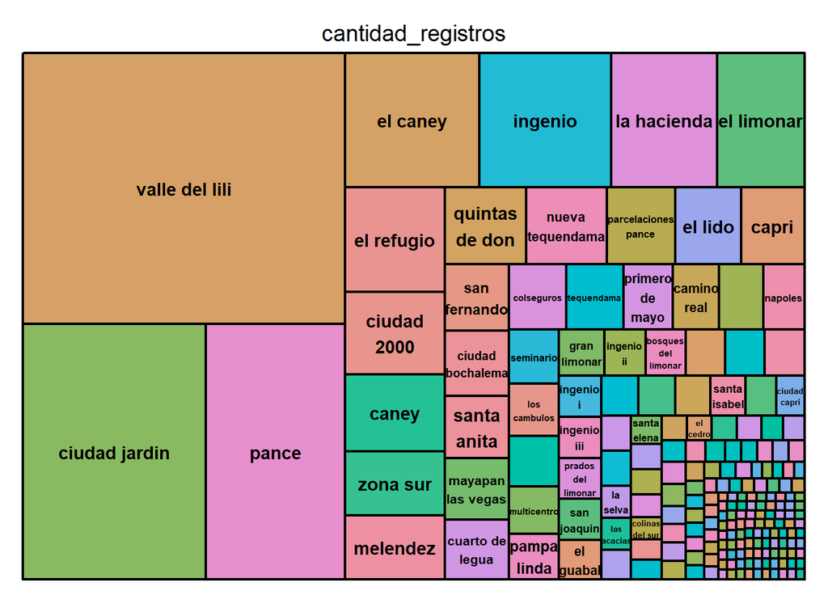

```r
treemap(resultados_barrios_sur,
        index = "barrio",
        vSize = "cantidad_registros",
        type = "index")
```

De acuerdo al anterior previamente realizado vamos a tomar como ejemplo los datos para el barrio del **Valle de Lili**, para ello definimos una nueva muestra de datos.

#### Valle de Lili

```r
data_viviendas_lili <- data_viviendas %>%
  select(piso, estrato, preciom, areaconst, parquea, banios, habitac, barrio, tipo) %>%
  filter(barrio == "valle del lili")

print(head(data_viviendas_lili,15))
```

```
##    piso estrato preciom areaconst parquea banios habitac         barrio
## 1    NA       5     275        74       1      2       3 valle del lili
## 2     2       4     225        85       1      2       3 valle del lili
## 3    NA       4     320       162       1      2       3 valle del lili
## 4     8       4     235        70       1      2       2 valle del lili
## 5     8       5     220        64       1      2       2 valle del lili
## 6     8       5     230        63       1      2       2 valle del lili
## 7     7       5     200        64       1      2       2 valle del lili
## 8     1       5     208        64       1      2       2 valle del lili
## 9    NA       4     160        54      NA      2       2 valle del lili
## 10   NA       5     220        64       1      2       2 valle del lili
## 11   NA       4     164        60      NA      2       2 valle del lili
## 12    6       4     165        59      NA      2       2 valle del lili
## 13    4       4     340        92       1      2       3 valle del lili
## 14    1       4     116        43      NA      2       2 valle del lili
```

[output cut: 17 more lines]

```
##       piso           estrato         preciom        areaconst
##  Min.   : 1.000   Min.   :3.000   Min.   :108.0   Min.   : 40.00
##  1st Qu.: 2.000   1st Qu.:4.000   1st Qu.:175.0   1st Qu.: 62.00
##  Median : 4.000   Median :4.000   Median :235.0   Median : 76.25
##  Mean   : 4.821   Mean   :4.426   Mean   :243.2   Mean   : 90.08
##  3rd Qu.: 7.000   3rd Qu.:5.000   3rd Qu.:289.2   3rd Qu.: 91.00
##  Max.   :12.000   Max.   :6.000   Max.   :800.0   Max.   :932.00
##  NA's   :247
##     parquea           banios        habitac         barrio
##  Min.   : 1.000   Min.   :1.00   Min.   :1.000   Length:1008
##  1st Qu.: 1.000   1st Qu.:2.00   1st Qu.:3.000   Class :character
##  Median : 1.000   Median :2.00   Median :3.000   Mode  :character
##  Mean   : 1.198   Mean   :2.38   Mean   :2.918
##  3rd Qu.: 1.000   3rd Qu.:3.00   3rd Qu.:3.000
##  Max.   :10.000   Max.   :8.00   Max.   :8.000
##  NA's   :171
##      tipo
##  Length:1008
##  Class :character
##  Mode  :character
##
##
##
##
```

A continuación, presentamos la representación gráfica correspondiente a esta muestra.

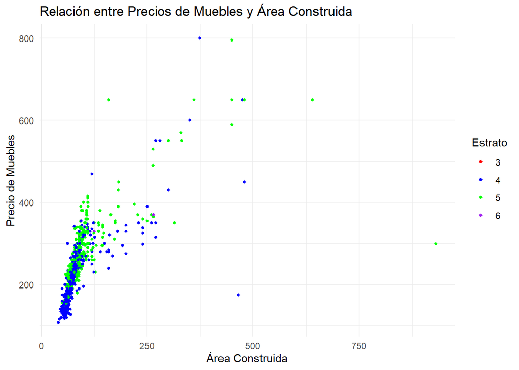

```r
grafico_lineal_lili <- ggplot(data_viviendas_lili, aes(x = areaconst, y = preciom)) +
  geom_point(aes(color = as.factor(estrato)), size = 1.0) +  # Ajustar el tamaño de las líneas
  labs(title = "Relación entre Precios de Muebles y Área Construida",
       x = "Área Construida",
       y = "Precio de Muebles",
       color = "Estrato") +
  scale_color_manual(values = c("red", "blue", "green", "purple", "orange")) +
  theme_minimal()

# Imprimir el gráfico lineal
print(grafico_lineal_lili)
```

Como se puede apreciar, la mayoría de las propiedades se concentran en los estratos 4 y 5, siendo especialmente notable la predominancia del estrato 4.

Vamos a realizar un zoom enfocandonos en aquellas areas menores a 250.

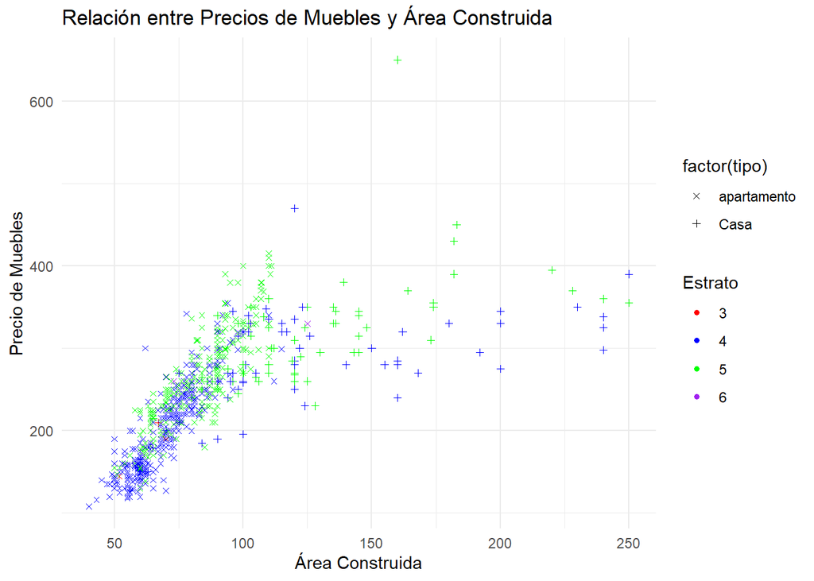

```r
data_viviendas_lili_250 <- data_viviendas_lili %>%
  filter(areaconst <= 250)

grafico_lineal_lili_250 <- ggplot(data_viviendas_lili_250, aes(x = areaconst, y = preciom)) +
  geom_point(aes(color = as.factor(estrato), shape = factor(tipo)), size = 1.2) +  # Ajustar el tamaño de las líneas
  labs(title = "Relación entre Precios de Muebles y Área Construida",
       x = "Área Construida",
       y = "Precio de Muebles",
       color = "Estrato") +
  scale_color_manual(values = c("red", "blue", "green", "purple", "orange")) +
  scale_shape_manual(values = c(4, 3)) +  # 4: Cruz, 3: Caja
  theme_minimal()

# Imprimir el gráfico lineal
print(grafico_lineal_lili_250)
```

Por otra parte, se requiere definir si en nuestra base de datos en valor para NA se refiere a que la propiedad no cuenta con parqueadero y si en definitiva son valores perdidos, ya que un estudio teniendo en cuenta el valor de las propiedades con este valor mejor definido mejoraria bastante nuestro analisis. Tal como se muestra en la siguiente tabla.

```r
data_viviendas_lili_250_p <- data_viviendas_lili_250 %>%
  group_by(parquea) %>%
  count() %>%
  select(parquea, cantidad_registros = n)

print(data_viviendas_lili_250_p)
```

```
## # A tibble: 6 × 2
## # Groups:   parquea [6]
##   parquea cantidad_registros
##     <int>              <int>
## 1       1                674
## 2       2                133
## 3       3                  3
## 4       4                  1
## 5      10                  1
## 6      NA                168
```

## Discusión

El análisis realizado hasta el momento nos ha proporcionado una visión general de los datos y ha señalado áreas clave para una exploración más profunda. En este sentido, hemos observado que la zona sur se destaca como la que registra la mayor cantidad de datos, lo que nos motiva a sumergirnos en un análisis más exhaustivo de esta región.

En respuesta a esta observación, hemos procedido a identificar un intervalo de área construida entre 55 y 65 metros cuadrados, destacando los valores máximo y mínimo dentro de esta franja. Este enfoque nos permite establecer parámetros más precisos para nuestro estudio y afinar nuestro análisis.

La distribución de las propiedades según la zona y su relación con el valor nos proporciona información valiosa. En particular, se destaca que las zonas norte, sur y oeste albergan propiedades de mayor valor, mientras que las zonas centro y oriente se caracterizan por propiedades más asequibles. La concentración de registros en la zona sur nos incentiva a un análisis más profundo de esta área, ya que la riqueza de información podría revelar patrones interesantes y oportunidades de estudio.

Un aspecto intrigante que se ha observado es la relación entre el área construida y el precio. Aunque el tamaño de las casas y apartamentos puede ser similar en ciertos casos, los precios varían significativamente. Resulta notable que algunas casas pueden tener precios más asequibles que los apartamentos, lo cual presenta una interesante oportunidad de negocio al adquirir y mejorar casas para su posterior venta.